# Perfecto-Sevilla_Quiz2.rmd

Covi Perfecto, Luis Carlo Sevilla

7/29/2021

#### Question 1:

An article in the Journal of Sound and Vibration [“Measurement of Noise-Evoked Blood Pressure by Means of Averaging Method: Relation between Blood Pressure Rise and PSL” (1991, Vol. 151(3), pp. 383-394)] described a study investigating the relationship between noise exposure and hypertension. The following data are representative of those reported in the article.

```
##    psl bpr
## 1   60   1
## 2   63   0
## 3   65   1
## 4   70   2
## 5   70   5
## 6   70   1
## 7   80   4
## 8   90   6
## 9   80   2
## 10  80   3
## 11  85   5
## 12  89   4
## 13  90   6
## 14  90   8
## 15  90   4
## 16  90   5
## 17  94   7
## 18 100   9
## 19 100   7
## 20 100   6
```

*A.Draw a scatter diagram of y (blood pressure rise in millimeters of mercury) versus x (sound pressure level in decibels). Does a simple linear regression model seem reasonable in this situation?*

It is reasonable to use the Linear Regression Model in analyzing this problem because the result that the research wants to answer is the relationship between the two variables— the sound pressure levels(dB) and blood pressure rise in millimeter of mercury.

We can utilize the library of *ggplot2* to create an accurate regression model of the sound pressure levels(dB) and blood pressure rise in millimeter of mercury. We can do so by calling the library of *ggplot2* and appointing the x and y values and using the **ggplot(data=MyDataFile, aes(x,y))** function.

[figure not shown]

```r
library(ggplot2)
scatterBPR_PSL=ggplot(data=BPR_PSL, aes(bpr,psl)) +
  geom_point()

scatterBPR_PSL = scatterBPR_PSL+ geom_point(size=2) +
  xlab("PSL (dB)") +
  ylab("Blood Pressure Rise (mmHg)") +
  ggtitle("Measurement of Noise-Evoked Blood Pressure")
scatterBPR_PSL
```

*B. Fit the simple linear regression model using least squares. Find an estimate of σ2.*

**Step 1:**

To fit a simple linear regression model, we can use the equation of the fitted or estimated regression line:

$$\hat{y} = \hat{\beta}_0 + \hat{\beta}_1x$$

where $\hat{\beta}_0$ and $\hat{\beta}_1x$ are represented (according to the least squares) as:

$$\hat{\beta}_0 = \bar{y} - \hat{\beta}_1\bar{x}$$

where $S_{xx} = \sum_{i = 1}^{n} x^2_i - \frac{(\sum_{i = 1}^{n} x_i)^2}{n}$, $S_{xy} = \sum_{i = 1}^{n} x_iy_i - \frac{(\sum_{i = 1}^{n} x_i)(\sum_{i = 1}^{n} y_i)}{n}$, $\bar{y} = (1/n) \sum_{i = 1}^{n} y_i$, and $\bar{x} = (1/n) \sum_{i = 1}^{n} x_i$

**Step 2:**

Let us get the required values to solve for the linear regression line using the functions of R:

The sample size:

$n = 20$ ;

$$\sum_{i = 1}^{20} x_i = 1656$$

```r
sumX = sum(psl); sumX
```

```
## [1] 1656
```

$$\sum_{i = 1}^{20} y_i = 86$$

```r
sumY = sum(bpr); sumY
```

```
## [1] 86
```

$$\bar{x} = 82.8$$

```r
barX = mean(psl); barX
```

```
## [1] 82.8
```

$$\bar{y} = 4.3$$

```r
barY = mean(bpr); barY
```

```
## [1] 4.3
```

$$\sum_{i = 1}^{20} x_i^2 = 140176$$

```r
sumXsqr = sum(psl^2); sumXsqr
```

```
## [1] 140176
```

$$\sum_{i = 1}^{20} y_i^2 = 494$$

```r
sumYsqr =sum(bpr^2); sumYsqr
```

```
## [1] 494
```

$$\sum_{i = 1}^{20} x_1 y_i = 7654$$

```r
sumXY = sum(bpr*psl); sumXY
```

```
## [1] 7654
```

$$S_{xx} = \sum_{i = 1}^{20} x^2_i - \frac{(\sum_{i = 1}^{20} x_i)^2}{n} = 140176 - \frac{1656^2}{20}= 3059.2$$

```r
Sxx = sumXsqr- ((sumX^2)/20); Sxx
```

```
## [1] 3059.2
```

$$S_{xy} = \sum_{i = 1}^{n} x_iy_i - \frac{(\sum_{i = 1}^{n} x_i)(\sum_{i = 1}^{n} y_i)}{n} = 7654 - \frac{(1656)(86)}{20} = 533.2$$

```r
Sxy = sumXY - ((sumX*sumY)/20); Sxy
```

```
## [1] 533.2
```

**Step 3:**

Therefore, the least squares estimates of the slope and intercepts are:

$$\hat{\beta}_1 = \frac{S_{xy}}{S_{xx}} = \frac{533.2}{3059.2} = 0.1742939$$

```r
betaHat1 = Sxy/Sxx; betaHat1
```

```
## [1] 0.1742939
```

and

```r
betHat0 = barY - (betaHat1*barX); betHat0
```

```
## [1] -10.13154
```

**Step 4:**

The fitted simple linear regression model (with the coefficients reported to three decimal places) is
$$\hat{y} = -10.132 + 0.174x$$
We can also check if our coefficients are correct by utilizing the *coef* function of ggplot:

```r
coeftest = lm(bpr~psl)
coef(coeftest)
```

```
## (Intercept)         psl
## -10.1315377   0.1742939
```

Here is the scatter plot with the fitted linear regression

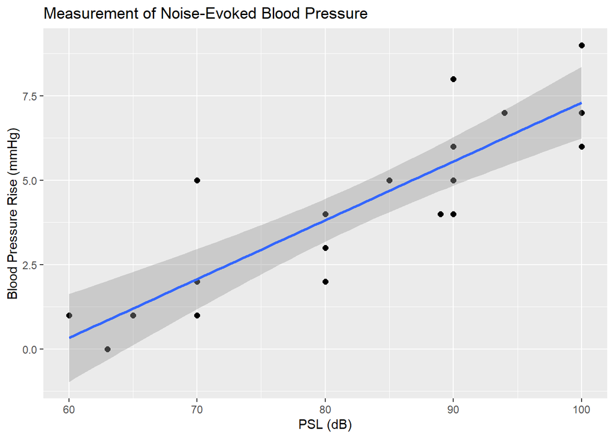

**Step 5:** Let us now find the estimate of $\sigma^2$:

To find the estimate of $\sigma^2$, we need to look for the value of $SS_E$ where

$$SS_E = \sum_{i = 1}^{n} (y_i - \hat{y})^2$$
We can also easily check the Squared Sum due to Errors by using the *dataBase$resduals* function of R:

```r
SSe = sum(scatterBPR_PSL$residuals^2); SSe
```

[output not shown]

finally, we can solve for $\sigma^2$ by

*C. Find the predicted mean rise in blood pressure level associated with a sound pressure level of 85 decibels.*

Since we already established the equation of the linear regression we can easily get the predicted mean rise in blood pressure level (y) associated with a sound pressure level of 85 decibels.

$$\hat{y} = -10.132 + 0.174x = -10.132 + 0.174(85)$$
Therefore,
$$\hat{y} = 4.658$$